# Risk Factor Analysis

## Outcome Variable

**Outcome Variable:** y_rate_len

## Predictor Variables

**Intervention Variable:** perdiar24

**Adjustment Set:**

- arm
- sex
- W_mage
- meducyrs
- feducyrs
- hhwealth_quart
- hfoodsec
- hdlvry
- W_birthwt
- W_birthlen
- W_nrooms
- month
- brthmon
- impfloor
- impsan
- safeh20
- delta_W_mage
- delta_meducyrs
- delta_feducyrs
- delta_hhwealth_quart
- delta_hfoodsec
- delta_hdlvry
- delta_W_birthwt
- delta_W_birthlen
- delta_W_nrooms
- delta_month
- delta_brthmon
- delta_impfloor
- delta_impsan
- delta_safeh20

## Stratifying Variables

The analysis was stratified on these variable(s):

- agecat
- studyid
- country

## Data Summary

| agecat | studyid | country | perdiar24 | n_cell | n |
| --- | --- | --- | --- | --- | --- |
| 0-3 months | ki0047075b-MAL-ED | BANGLADESH | Q1 | 16 | 244 |
| 0-3 months | ki0047075b-MAL-ED | BANGLADESH | Q2 | 49 | 244 |
| 0-3 months | ki0047075b-MAL-ED | BANGLADESH | Q3 | 97 | 244 |
| 0-3 months | ki0047075b-MAL-ED | BANGLADESH | Q4 | 82 | 244 |
| 0-3 months | ki1017093-NIH-Birth | BANGLADESH | Q1 | 43 | 566 |
| 0-3 months | ki1017093-NIH-Birth | BANGLADESH | Q2 | 122 | 566 |
| 0-3 months | ki1017093-NIH-Birth | BANGLADESH | Q3 | 223 | 566 |
| 0-3 months | ki1017093-NIH-Birth | BANGLADESH | Q4 | 178 | 566 |
| 0-3 months | ki1017093b-PROVIDE | BANGLADESH | Q1 | 52 | 634 |
| 0-3 months | ki1017093b-PROVIDE | BANGLADESH | Q2 | 163 | 634 |
| 0-3 months | ki1017093b-PROVIDE | BANGLADESH | Q3 | 253 | 634 |
| 0-3 months | ki1017093b-PROVIDE | BANGLADESH | Q4 | 166 | 634 |
| 0-3 months | ki1017093c-NIH-Crypto | BANGLADESH | Q1 | 168 | 720 |
| 0-3 months | ki1017093c-NIH-Crypto | BANGLADESH | Q2 | 184 | 720 |
| 0-3 months | ki1017093c-NIH-Crypto | BANGLADESH | Q3 | 191 | 720 |
| 0-3 months | ki1017093c-NIH-Crypto | BANGLADESH | Q4 | 177 | 720 |
| 0-3 months | ki1114097-CMIN | BANGLADESH | Q2 | 4 | 43 |
| 0-3 months | ki1114097-CMIN | BANGLADESH | Q3 | 17 | 43 |
| 0-3 months | ki1114097-CMIN | BANGLADESH | Q4 | 22 | 43 |
| 0-3 months | kiGH5241-JiVitA-4 | BANGLADESH | Q1 | 667 | 1807 |
| 0-3 months | kiGH5241-JiVitA-4 | BANGLADESH | Q2 | 584 | 1807 |
| 0-3 months | kiGH5241-JiVitA-4 | BANGLADESH | Q3 | 421 | 1807 |
| 0-3 months | kiGH5241-JiVitA-4 | BANGLADESH | Q4 | 135 | 1807 |
| 0-3 months | ki0047075b-MAL-ED | BRAZIL | Q1 | 112 | 180 |
| 0-3 months | ki0047075b-MAL-ED | BRAZIL | Q2 | 53 | 180 |
| 0-3 months | ki0047075b-MAL-ED | BRAZIL | Q3 | 14 | 180 |
| 0-3 months | ki0047075b-MAL-ED | BRAZIL | Q4 | 1 | 180 |
| 0-3 months | ki1114097-CMIN | BRAZIL | Q1 | 7 | 81 |
| 0-3 months | ki1114097-CMIN | BRAZIL | Q2 | 17 | 81 |
| 0-3 months | ki1114097-CMIN | BRAZIL | Q3 | 24 | 81 |

[output cut: 249 more lines]

The following strata were considered:

- agecat: 0-3 months, studyid: ki0047075b-MAL-ED, country: BANGLADESH
- agecat: 0-3 months, studyid: ki0047075b-MAL-ED, country: BRAZIL
- agecat: 0-3 months, studyid: ki0047075b-MAL-ED, country: INDIA
- agecat: 0-3 months, studyid: ki0047075b-MAL-ED, country: NEPAL
- agecat: 0-3 months, studyid: ki0047075b-MAL-ED, country: PERU
- agecat: 0-3 months, studyid: ki0047075b-MAL-ED, country: SOUTH AFRICA
- agecat: 0-3 months, studyid: ki0047075b-MAL-ED, country: TANZANIA, UNITED REPUBLIC OF
- agecat: 0-3 months, studyid: ki1000109-EE, country: PAKISTAN
- agecat: 0-3 months, studyid: ki1000109-ResPak, country: PAKISTAN
- agecat: 0-3 months, studyid: ki1017093-NIH-Birth, country: BANGLADESH
- agecat: 0-3 months, studyid: ki1017093b-PROVIDE, country: BANGLADESH
- agecat: 0-3 months, studyid: ki1017093c-NIH-Crypto, country: BANGLADESH
- agecat: 0-3 months, studyid: ki1114097-CMIN, country: BANGLADESH
- agecat: 0-3 months, studyid: ki1114097-CMIN, country: BRAZIL
- agecat: 0-3 months, studyid: ki1114097-CMIN, country: GUINEA-BISSAU
- agecat: 0-3 months, studyid: ki1114097-CMIN, country: PERU
- agecat: 0-3 months, studyid: ki1114097-CONTENT, country: PERU
- agecat: 0-3 months, studyid: kiGH5241-JiVitA-4, country: BANGLADESH
- agecat: 12-24 months, studyid: ki0047075b-MAL-ED, country: BANGLADESH
- agecat: 12-24 months, studyid: ki0047075b-MAL-ED, country: BRAZIL
- agecat: 12-24 months, studyid: ki0047075b-MAL-ED, country: INDIA
- agecat: 12-24 months, studyid: ki0047075b-MAL-ED, country: NEPAL
- agecat: 12-24 months, studyid: ki0047075b-MAL-ED, country: PERU
- agecat: 12-24 months, studyid: ki0047075b-MAL-ED, country: SOUTH AFRICA
- agecat: 12-24 months, studyid: ki0047075b-MAL-ED, country: TANZANIA, UNITED REPUBLIC OF
- agecat: 12-24 months, studyid: ki1017093-NIH-Birth, country: BANGLADESH
- agecat: 12-24 months, studyid: ki1017093b-PROVIDE, country: BANGLADESH
- agecat: 12-24 months, studyid: ki1017093c-NIH-Crypto, country: BANGLADESH
- agecat: 12-24 months, studyid: ki1114097-CMIN, country: BANGLADESH
- agecat: 12-24 months, studyid: ki1114097-CMIN, country: GUINEA-BISSAU
- agecat: 12-24 months, studyid: ki1114097-CMIN, country: PERU
- agecat: 12-24 months, studyid: ki1114097-CONTENT, country: PERU
- agecat: 12-24 months, studyid: kiGH5241-JiVitA-4, country: BANGLADESH
- agecat: 3-6 months, studyid: ki0047075b-MAL-ED, country: BANGLADESH
- agecat: 3-6 months, studyid: ki0047075b-MAL-ED, country: BRAZIL
- agecat: 3-6 months, studyid: ki0047075b-MAL-ED, country: INDIA
- agecat: 3-6 months, studyid: ki0047075b-MAL-ED, country: NEPAL
- agecat: 3-6 months, studyid: ki0047075b-MAL-ED, country: PERU
- agecat: 3-6 months, studyid: ki0047075b-MAL-ED, country: SOUTH AFRICA
- agecat: 3-6 months, studyid: ki0047075b-MAL-ED, country: TANZANIA, UNITED REPUBLIC OF
- agecat: 3-6 months, studyid: ki1000109-EE, country: PAKISTAN
- agecat: 3-6 months, studyid: ki1000109-ResPak, country: PAKISTAN
- agecat: 3-6 months, studyid: ki1017093-NIH-Birth, country: BANGLADESH
- agecat: 3-6 months, studyid: ki1017093b-PROVIDE, country: BANGLADESH
- agecat: 3-6 months, studyid: ki1017093c-NIH-Crypto, country: BANGLADESH
- agecat: 3-6 months, studyid: ki1114097-CMIN, country: BANGLADESH
- agecat: 3-6 months, studyid: ki1114097-CMIN, country: BRAZIL
- agecat: 3-6 months, studyid: ki1114097-CMIN, country: GUINEA-BISSAU
- agecat: 3-6 months, studyid: ki1114097-CMIN, country: PERU
- agecat: 3-6 months, studyid: ki1114097-CONTENT, country: PERU
- agecat: 3-6 months, studyid: kiGH5241-JiVitA-4, country: BANGLADESH
- agecat: 6-12 months, studyid: ki0047075b-MAL-ED, country: BANGLADESH
- agecat: 6-12 months, studyid: ki0047075b-MAL-ED, country: BRAZIL
- agecat: 6-12 months, studyid: ki0047075b-MAL-ED, country: INDIA
- agecat: 6-12 months, studyid: ki0047075b-MAL-ED, country: NEPAL
- agecat: 6-12 months, studyid: ki0047075b-MAL-ED, country: PERU
- agecat: 6-12 months, studyid: ki0047075b-MAL-ED, country: SOUTH AFRICA
- agecat: 6-12 months, studyid: ki0047075b-MAL-ED, country: TANZANIA, UNITED REPUBLIC OF
- agecat: 6-12 months, studyid: ki1000109-EE, country: PAKISTAN
- agecat: 6-12 months, studyid: ki1000109-ResPak, country: PAKISTAN
- agecat: 6-12 months, studyid: ki1000304b-SAS-FoodSuppl, country: INDIA
- agecat: 6-12 months, studyid: ki1017093-NIH-Birth, country: BANGLADESH
- agecat: 6-12 months, studyid: ki1017093b-PROVIDE, country: BANGLADESH
- agecat: 6-12 months, studyid: ki1017093c-NIH-Crypto, country: BANGLADESH
- agecat: 6-12 months, studyid: ki1112895-Guatemala BSC, country: GUATEMALA
- agecat: 6-12 months, studyid: ki1114097-CMIN, country: BANGLADESH
- agecat: 6-12 months, studyid: ki1114097-CMIN, country: BRAZIL
- agecat: 6-12 months, studyid: ki1114097-CMIN, country: GUINEA-BISSAU
- agecat: 6-12 months, studyid: ki1114097-CMIN, country: PERU
- agecat: 6-12 months, studyid: ki1114097-CONTENT, country: PERU
- agecat: 6-12 months, studyid: kiGH5241-JiVitA-4, country: BANGLADESH

### Dropped Strata

Some strata were dropped due to rare outcomes:

- agecat: 0-3 months, studyid: ki1114097-CMIN, country: BANGLADESH
- agecat: 0-3 months, studyid: ki0047075b-MAL-ED, country: BRAZIL
- agecat: 0-3 months, studyid: ki1114097-CMIN, country: GUINEA-BISSAU
- agecat: 0-3 months, studyid: ki1000109-ResPak, country: PAKISTAN
- agecat: 0-3 months, studyid: ki1114097-CONTENT, country: PERU
- agecat: 0-3 months, studyid: ki0047075b-MAL-ED, country: SOUTH AFRICA
- agecat: 3-6 months, studyid: ki1114097-CMIN, country: BANGLADESH
- agecat: 3-6 months, studyid: ki0047075b-MAL-ED, country: BRAZIL
- agecat: 3-6 months, studyid: ki1114097-CMIN, country: GUINEA-BISSAU
- agecat: 3-6 months, studyid: ki0047075b-MAL-ED, country: SOUTH AFRICA
- agecat: 6-12 months, studyid: ki1114097-CMIN, country: BANGLADESH
- agecat: 6-12 months, studyid: ki0047075b-MAL-ED, country: BRAZIL
- agecat: 6-12 months, studyid: ki1000109-EE, country: PAKISTAN
- agecat: 6-12 months, studyid: ki0047075b-MAL-ED, country: PERU
- agecat: 6-12 months, studyid: ki0047075b-MAL-ED, country: SOUTH AFRICA
- agecat: 12-24 months, studyid: ki1114097-CMIN, country: BANGLADESH
- agecat: 12-24 months, studyid: ki1114097-CMIN, country: GUINEA-BISSAU
- agecat: 12-24 months, studyid: ki0047075b-MAL-ED, country: PERU
- agecat: 12-24 months, studyid: ki1114097-CONTENT, country: PERU
- agecat: 12-24 months, studyid: ki0047075b-MAL-ED, country: SOUTH AFRICA

## Methods Detail

We’re interested in the causal parameters $E[Y_a]$ for all values of $a \in \mathcal{A}$. These parameters represent the mean outcome if, possibly contrary to fact, we intervened to set all units to have $A=a$. Under the randomization and positivity assumptions, these are identified by the statistical parameters $\psi_a=E_W[E_{Y|A,W}(Y|A=a,W)]$. In addition, we’re interested in the mean of $Y$, $E[Y]$ under no intervention (the observed mean). We will estimate these parameters by using SuperLearner to fit the relevant likelihood factors – $E_{Y|A,W}(Y|A=a,W)$ and $p(A=a|W)$, and then updating our likelihood fit using a joint TMLE.

For unadjusted analyses ($W=\{\}$), initial likelihoods were estimated using Lrnr_glm to estimate the simple $E(Y|A)$ and Lrnr_mean to estimate $p(A)$. For adjusted analyses, a small library containing Lrnr_glmnet, Lrnr_xgboost, and Lrnr_mean was used.

Having estimated these parameters, we will then use the delta method to estimate relative risks and attributable risks relative to a prespecified baseline level of $A$.

[output not shown]

# Results Detail

## Results Plots

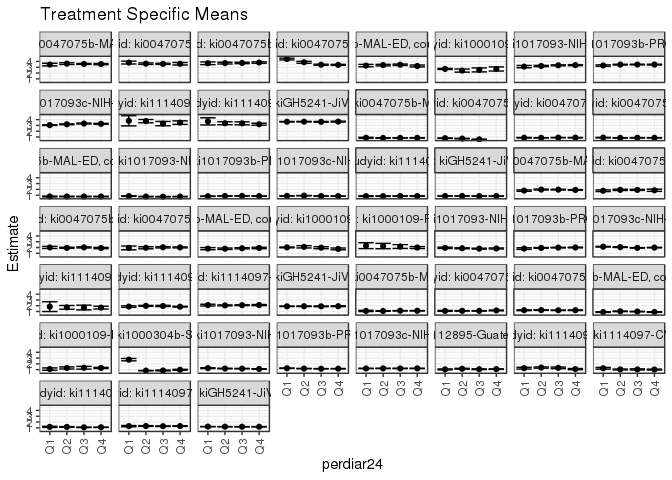

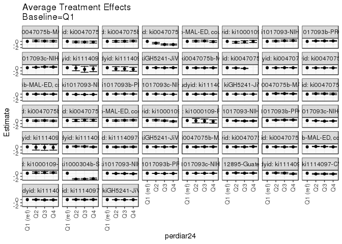

## Results Table

### Parameter: TSM

| agecat | studyid | country | intervention_level | baseline_level | estimate | ci_lower | ci_upper |
| --- | --- | --- | --- | --- | --- | --- | --- |
| 0-3 months | ki0047075b-MAL-ED | BANGLADESH | Q1 | NA | 3.4620302 | 3.2384279 | 3.6856326 |
| 0-3 months | ki0047075b-MAL-ED | BANGLADESH | Q2 | NA | 3.6247629 | 3.4739437 | 3.7755820 |
| 0-3 months | ki0047075b-MAL-ED | BANGLADESH | Q3 | NA | 3.5669848 | 3.4820838 | 3.6518857 |
| 0-3 months | ki0047075b-MAL-ED | BANGLADESH | Q4 | NA | 3.5424223 | 3.4258002 | 3.6590445 |
| 0-3 months | ki0047075b-MAL-ED | INDIA | Q1 | NA | 3.8066687 | 3.5675068 | 4.0458307 |
| 0-3 months | ki0047075b-MAL-ED | INDIA | Q2 | NA | 3.6170547 | 3.4885885 | 3.7455210 |
| 0-3 months | ki0047075b-MAL-ED | INDIA | Q3 | NA | 3.5912221 | 3.4864742 | 3.6959701 |
| 0-3 months | ki0047075b-MAL-ED | INDIA | Q4 | NA | 3.6001555 | 3.3875006 | 3.8128103 |
| 0-3 months | ki0047075b-MAL-ED | NEPAL | Q1 | NA | 3.6900736 | 3.4568342 | 3.9233130 |
| 0-3 months | ki0047075b-MAL-ED | NEPAL | Q2 | NA | 3.7130166 | 3.5659278 | 3.8601054 |
| 0-3 months | ki0047075b-MAL-ED | NEPAL | Q3 | NA | 3.7357799 | 3.6254418 | 3.8461180 |
| 0-3 months | ki0047075b-MAL-ED | NEPAL | Q4 | NA | 3.8149386 | 3.6963667 | 3.9335106 |
| 0-3 months | ki0047075b-MAL-ED | PERU | Q1 | NA | 4.4189163 | 4.2690580 | 4.5687746 |
| 0-3 months | ki0047075b-MAL-ED | PERU | Q2 | NA | 3.8567207 | 3.6933914 | 4.0200501 |
| 0-3 months | ki0047075b-MAL-ED | PERU | Q3 | NA | 3.4354151 | 3.3379608 | 3.5328695 |
| 0-3 months | ki0047075b-MAL-ED | PERU | Q4 | NA | 3.4152790 | 3.3266503 | 3.5039076 |
| 0-3 months | ki0047075b-MAL-ED | TANZANIA, UNITED REPUBLIC OF | Q1 | NA | 3.2863214 | 3.0802480 | 3.4923949 |
| 0-3 months | ki0047075b-MAL-ED | TANZANIA, UNITED REPUBLIC OF | Q2 | NA | 3.3729256 | 3.2389560 | 3.5068952 |
| 0-3 months | ki0047075b-MAL-ED | TANZANIA, UNITED REPUBLIC OF | Q3 | NA | 3.4325069 | 3.3176435 | 3.5473704 |
| 0-3 months | ki0047075b-MAL-ED | TANZANIA, UNITED REPUBLIC OF | Q4 | NA | 3.2197199 | 3.0571641 | 3.3822756 |
| 0-3 months | ki1000109-EE | PAKISTAN | Q1 | NA | 2.7057594 | 2.6175778 | 2.7939411 |
| 0-3 months | ki1000109-EE | PAKISTAN | Q2 | NA | 2.4240507 | 2.1570254 | 2.6910761 |
| 0-3 months | ki1000109-EE | PAKISTAN | Q3 | NA | 2.5389429 | 2.1941533 | 2.8837325 |
| 0-3 months | ki1000109-EE | PAKISTAN | Q4 | NA | 2.6992111 | 2.3420006 | 3.0564217 |
| 0-3 months | ki1017093-NIH-Birth | BANGLADESH | Q1 | NA | 3.1075775 | 2.9151077 | 3.3000472 |
| 0-3 months | ki1017093-NIH-Birth | BANGLADESH | Q2 | NA | 3.2141950 | 3.1108216 | 3.3175685 |
| 0-3 months | ki1017093-NIH-Birth | BANGLADESH | Q3 | NA | 3.3309783 | 3.2518289 | 3.4101278 |
| 0-3 months | ki1017093-NIH-Birth | BANGLADESH | Q4 | NA | 3.3680379 | 3.2737804 | 3.4622953 |
| 0-3 months | ki1017093b-PROVIDE | BANGLADESH | Q1 | NA | 3.2982608 | 3.1784816 | 3.4180400 |
| 0-3 months | ki1017093b-PROVIDE | BANGLADESH | Q2 | NA | 3.4538718 | 3.3886627 | 3.5190810 |

[output cut: 173 more lines]

### Parameter: E(Y)

| agecat | studyid | country | intervention_level | baseline_level | estimate | ci_lower | ci_upper |
| --- | --- | --- | --- | --- | --- | --- | --- |
| 0-3 months | ki0047075b-MAL-ED | BANGLADESH | NA | NA | 3.5634447 | 3.5006347 | 3.6262547 |
| 0-3 months | ki0047075b-MAL-ED | INDIA | NA | NA | 3.5764512 | 3.4977133 | 3.6551891 |
| 0-3 months | ki0047075b-MAL-ED | NEPAL | NA | NA | 3.8204935 | 3.7444190 | 3.8965681 |
| 0-3 months | ki0047075b-MAL-ED | PERU | NA | NA | 3.3158605 | 3.2526447 | 3.3790763 |
| 0-3 months | ki0047075b-MAL-ED | TANZANIA, UNITED REPUBLIC OF | NA | NA | 3.4816904 | 3.4044928 | 3.5588880 |
| 0-3 months | ki1000109-EE | PAKISTAN | NA | NA | 2.6575645 | 2.5739973 | 2.7411317 |
| 0-3 months | ki1017093-NIH-Birth | BANGLADESH | NA | NA | 3.3129255 | 3.2581305 | 3.3677204 |
| 0-3 months | ki1017093b-PROVIDE | BANGLADESH | NA | NA | 3.4826706 | 3.4434873 | 3.5218539 |
| 0-3 months | ki1017093c-NIH-Crypto | BANGLADESH | NA | NA | 3.3028656 | 3.2646714 | 3.3410598 |
| 0-3 months | ki1114097-CMIN | BRAZIL | NA | NA | 3.5146220 | 3.3089330 | 3.7203110 |
| 0-3 months | ki1114097-CMIN | PERU | NA | NA | 3.3155510 | 3.1827969 | 3.4483051 |
| 0-3 months | kiGH5241-JiVitA-4 | BANGLADESH | NA | NA | 3.6381167 | 3.6070177 | 3.6692156 |
| 3-6 months | ki0047075b-MAL-ED | BANGLADESH | NA | NA | 1.9280462 | 1.8787523 | 1.9773401 |
| 3-6 months | ki0047075b-MAL-ED | INDIA | NA | NA | 1.8837264 | 1.8224393 | 1.9450135 |
| 3-6 months | ki0047075b-MAL-ED | NEPAL | NA | NA | 1.9680995 | 1.9120346 | 2.0241643 |
| 3-6 months | ki0047075b-MAL-ED | PERU | NA | NA | 2.0183213 | 1.9525900 | 2.0840526 |
| 3-6 months | ki0047075b-MAL-ED | TANZANIA, UNITED REPUBLIC OF | NA | NA | 1.8300902 | 1.7622436 | 1.8979368 |
| 3-6 months | ki1000109-EE | PAKISTAN | NA | NA | 2.0241201 | 1.9636505 | 2.0845898 |
| 3-6 months | ki1000109-ResPak | PAKISTAN | NA | NA | 2.0694234 | 1.9275918 | 2.2112551 |
| 3-6 months | ki1017093-NIH-Birth | BANGLADESH | NA | NA | 1.8326915 | 1.7846731 | 1.8807099 |
| 3-6 months | ki1017093b-PROVIDE | BANGLADESH | NA | NA | 1.9654454 | 1.9303798 | 2.0005110 |
| 3-6 months | ki1017093c-NIH-Crypto | BANGLADESH | NA | NA | 2.0057973 | 1.9693775 | 2.0422170 |
| 3-6 months | ki1114097-CMIN | BRAZIL | NA | NA | 1.6962691 | 1.5066453 | 1.8858929 |
| 3-6 months | ki1114097-CMIN | PERU | NA | NA | 1.8940471 | 1.8464513 | 1.9416429 |
| 3-6 months | ki1114097-CONTENT | PERU | NA | NA | 2.0841841 | 2.0362519 | 2.1321163 |
| 3-6 months | kiGH5241-JiVitA-4 | BANGLADESH | NA | NA | 1.8983676 | 1.8684335 | 1.9283018 |
| 6-12 months | ki0047075b-MAL-ED | BANGLADESH | NA | NA | 1.1143928 | 1.0896103 | 1.1391753 |
| 6-12 months | ki0047075b-MAL-ED | INDIA | NA | NA | 1.1210558 | 1.0926349 | 1.1494766 |
| 6-12 months | ki0047075b-MAL-ED | NEPAL | NA | NA | 1.2224454 | 1.1966480 | 1.2482429 |
| 6-12 months | ki0047075b-MAL-ED | TANZANIA, UNITED REPUBLIC OF | NA | NA | 1.0019524 | 0.9648566 | 1.0390481 |
| 6-12 months | ki1000109-ResPak | PAKISTAN | NA | NA | 1.2964732 | 1.2129800 | 1.3799664 |
| 6-12 months | ki1000304b-SAS-FoodSuppl | INDIA | NA | NA | 1.0131058 | 0.9370457 | 1.0891660 |
| 6-12 months | ki1017093-NIH-Birth | BANGLADESH | NA | NA | 1.1679344 | 1.1454934 | 1.1903754 |
| 6-12 months | ki1017093b-PROVIDE | BANGLADESH | NA | NA | 1.1731762 | 1.1558671 | 1.1904853 |
| 6-12 months | ki1017093c-NIH-Crypto | BANGLADESH | NA | NA | 1.2281313 | 1.2106849 | 1.2455776 |
| 6-12 months | ki1112895-Guatemala BSC | GUATEMALA | NA | NA | 1.1083850 | 1.0774528 | 1.1393172 |
| 6-12 months | ki1114097-CMIN | BRAZIL | NA | NA | 1.2407866 | 1.1634646 | 1.3181086 |
| 6-12 months | ki1114097-CMIN | GUINEA-BISSAU | NA | NA | 1.0550158 | 1.0038610 | 1.1061707 |
| 6-12 months | ki1114097-CMIN | PERU | NA | NA | 1.1101018 | 1.0850311 | 1.1351725 |
| 6-12 months | ki1114097-CONTENT | PERU | NA | NA | 1.3010517 | 1.2719491 | 1.3301542 |
| 6-12 months | kiGH5241-JiVitA-4 | BANGLADESH | NA | NA | 1.2032186 | 1.1928228 | 1.2136143 |
| 12-24 months | ki0047075b-MAL-ED | BANGLADESH | NA | NA | 0.8459764 | 0.8299714 | 0.8619814 |
| 12-24 months | ki0047075b-MAL-ED | BRAZIL | NA | NA | 0.9816245 | 0.9508764 | 1.0123725 |
| 12-24 months | ki0047075b-MAL-ED | INDIA | NA | NA | 0.8803730 | 0.8630530 | 0.8976931 |
| 12-24 months | ki0047075b-MAL-ED | NEPAL | NA | NA | 0.8617083 | 0.8463512 | 0.8770654 |
| 12-24 months | ki0047075b-MAL-ED | TANZANIA, UNITED REPUBLIC OF | NA | NA | 0.7663111 | 0.7428636 | 0.7897586 |
| 12-24 months | ki1017093-NIH-Birth | BANGLADESH | NA | NA | 0.7513013 | 0.7366996 | 0.7659029 |
| 12-24 months | ki1017093b-PROVIDE | BANGLADESH | NA | NA | 0.8575519 | 0.8455586 | 0.8695452 |
| 12-24 months | ki1017093c-NIH-Crypto | BANGLADESH | NA | NA | 0.8755729 | 0.8637860 | 0.8873598 |
| 12-24 months | ki1114097-CMIN | PERU | NA | NA | 0.8385504 | 0.8202134 | 0.8568875 |
| 12-24 months | kiGH5241-JiVitA-4 | BANGLADESH | NA | NA | 0.8491886 | 0.8437514 | 0.8546258 |

### Parameter: ATE

| agecat | studyid | country | intervention_level | baseline_level | estimate | ci_lower | ci_upper |
| --- | --- | --- | --- | --- | --- | --- | --- |
| 0-3 months | ki0047075b-MAL-ED | BANGLADESH | Q1 | Q1 | 0.0000000 | 0.0000000 | 0.0000000 |
| 0-3 months | ki0047075b-MAL-ED | BANGLADESH | Q2 | Q1 | 0.1627326 | -0.1062190 | 0.4316843 |
| 0-3 months | ki0047075b-MAL-ED | BANGLADESH | Q3 | Q1 | 0.1049545 | -0.1336473 | 0.3435564 |
| 0-3 months | ki0047075b-MAL-ED | BANGLADESH | Q4 | Q1 | 0.0803921 | -0.1709564 | 0.3317406 |
| 0-3 months | ki0047075b-MAL-ED | INDIA | Q1 | Q1 | 0.0000000 | 0.0000000 | 0.0000000 |
| 0-3 months | ki0047075b-MAL-ED | INDIA | Q2 | Q1 | -0.1896140 | -0.4598039 | 0.0805758 |
| 0-3 months | ki0047075b-MAL-ED | INDIA | Q3 | Q1 | -0.2154466 | -0.4754386 | 0.0445453 |
| 0-3 months | ki0047075b-MAL-ED | INDIA | Q4 | Q1 | -0.2065133 | -0.5258225 | 0.1127960 |
| 0-3 months | ki0047075b-MAL-ED | NEPAL | Q1 | Q1 | 0.0000000 | 0.0000000 | 0.0000000 |
| 0-3 months | ki0047075b-MAL-ED | NEPAL | Q2 | Q1 | 0.0229430 | -0.2479220 | 0.2938080 |
| 0-3 months | ki0047075b-MAL-ED | NEPAL | Q3 | Q1 | 0.0457063 | -0.2085042 | 0.2999168 |
| 0-3 months | ki0047075b-MAL-ED | NEPAL | Q4 | Q1 | 0.1248650 | -0.1329301 | 0.3826602 |
| 0-3 months | ki0047075b-MAL-ED | PERU | Q1 | Q1 | 0.0000000 | 0.0000000 | 0.0000000 |
| 0-3 months | ki0047075b-MAL-ED | PERU | Q2 | Q1 | -0.5621955 | -0.7834580 | -0.3409331 |
| 0-3 months | ki0047075b-MAL-ED | PERU | Q3 | Q1 | -0.9835011 | -1.1622388 | -0.8047634 |
| 0-3 months | ki0047075b-MAL-ED | PERU | Q4 | Q1 | -1.0036373 | -1.1784110 | -0.8288636 |
| 0-3 months | ki0047075b-MAL-ED | TANZANIA, UNITED REPUBLIC OF | Q1 | Q1 | 0.0000000 | 0.0000000 | 0.0000000 |
| 0-3 months | ki0047075b-MAL-ED | TANZANIA, UNITED REPUBLIC OF | Q2 | Q1 | 0.0866041 | -0.1593292 | 0.3325375 |
| 0-3 months | ki0047075b-MAL-ED | TANZANIA, UNITED REPUBLIC OF | Q3 | Q1 | 0.1461855 | -0.0899562 | 0.3823272 |
| 0-3 months | ki0047075b-MAL-ED | TANZANIA, UNITED REPUBLIC OF | Q4 | Q1 | -0.0666016 | -0.3296152 | 0.1964121 |
| 0-3 months | ki1000109-EE | PAKISTAN | Q1 | Q1 | 0.0000000 | 0.0000000 | 0.0000000 |
| 0-3 months | ki1000109-EE | PAKISTAN | Q2 | Q1 | -0.2817087 | -0.5611675 | -0.0022500 |
| 0-3 months | ki1000109-EE | PAKISTAN | Q3 | Q1 | -0.1668166 | -0.5219605 | 0.1883273 |
| 0-3 months | ki1000109-EE | PAKISTAN | Q4 | Q1 | -0.0065483 | -0.3742038 | 0.3611072 |
| 0-3 months | ki1017093-NIH-Birth | BANGLADESH | Q1 | Q1 | 0.0000000 | 0.0000000 | 0.0000000 |
| 0-3 months | ki1017093-NIH-Birth | BANGLADESH | Q2 | Q1 | 0.1066176 | -0.1111709 | 0.3244060 |
| 0-3 months | ki1017093-NIH-Birth | BANGLADESH | Q3 | Q1 | 0.2234009 | 0.0164527 | 0.4303490 |
| 0-3 months | ki1017093-NIH-Birth | BANGLADESH | Q4 | Q1 | 0.2604604 | 0.0473070 | 0.4736138 |
| 0-3 months | ki1017093b-PROVIDE | BANGLADESH | Q1 | Q1 | 0.0000000 | 0.0000000 | 0.0000000 |
| 0-3 months | ki1017093b-PROVIDE | BANGLADESH | Q2 | Q1 | 0.1556111 | 0.0192111 | 0.2920110 |

[output cut: 173 more lines]